# HW_3_Individual

Volodymyr Kotov

2023-01-30

# Task to complete

- For this task use *debt* dataset depicting changes in debt-to-GDP ratio in EU
- Drop the line corresponding to your birth day + 1 - somebody born on the 21st would drop line 22 (1st line contains names)
- First, produce a scatter plot with Debt_to_GDP in 2003 on x-axis, Debt_to_GDP in 2007 on y-axis and country names as text labels
- Second, produce colored dendrogram with 3 clusters
- Third, generate a heatmap with any color palette instead of green including Debt_to_GDP for all years

Loading libraries:

```r
#if(!require("quantmod")) install.packages("quantmod")
#if(!require("ggrepel")) install.packages("ggrepel")
#if(!require("corrplot")) install.packages("corrplot")
#if(!require("ggraph")) install.packages("ggraph")
#if(!require("igraph")) install.packages("igraph")
#if(!require("dendroextras")) install.packages("dendroextras")
#if(!require("ape")) install.packages("ape")

library(quantmod)
library(readxl)
library(tidyverse)
library(dplyr)
library(ggplot2)
library(ggrepel)
library(ggraph)
library(igraph)
library(dendroextras)
library(ape)
```

Uploading data:

```r
data_1 <- read_xlsx("Data_Shrink_Debt.xlsx", sheet = "debt")
```

- Drop the line corresponding to your birth day + 1 - somebody born on the 21st would drop line 22 (1st line contains names). My birhday day is the 17th, so lets remove this line.

```r
data_1 <- as.data.frame(data_1)
data_2 <- data_1 %>%
  filter(., row_number(data_1) != 17)
```

# Scatter Plot

- First, produce a scatter plot with Debt_to_GDP in 2003 on x-axis, Debt_to_GDP in 2007 on y-axis and country names as text labels:

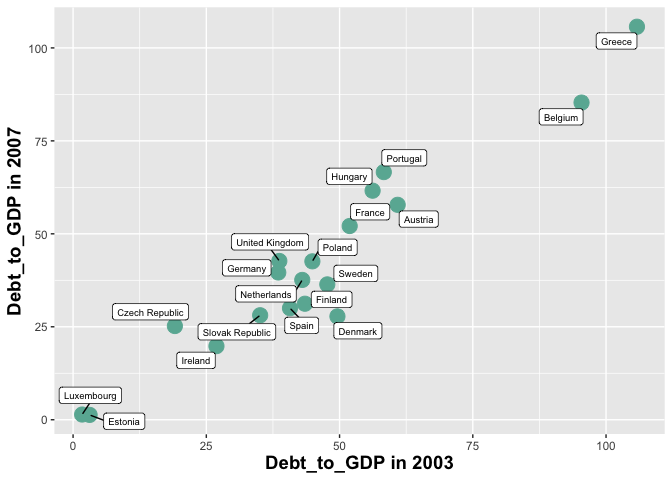

```r
ggplot(data_2, aes(x = data_2$Debt_to_GDP_Ratio_2003, y = data_2$Debt_to_GDP_Ratio_2007)) +
  geom_point(color = "#69b3a2", size = 5) +
  geom_label_repel(label = data_2$Country,  size=2.5) +
  labs(
    x = "Debt_to_GDP in 2003",
    y = "Debt_to_GDP in 2007"
  ) +
  theme(
    axis.title.x = element_text(color = "black", size = 14, face = "bold"),
    axis.title.y = element_text(color = "black", size = 14, face = "bold")
  )
```

# Dendogram

- Second, produce colored dendrogram with 3 clusters:

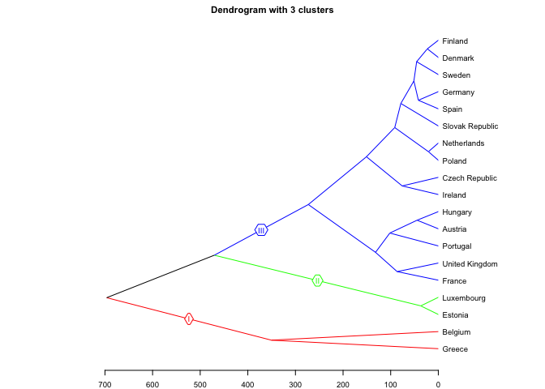

```r
data_3 <- data_2
rownames(data_3) <- data_2$Country
data_dist_matrix = dist(data_3, method = "euclidean")
data_clustered = hclust(data_dist_matrix)

par(mar = c(2,10,2,10), cex = 0.6)
data_clustered_1 = colour_clusters(hclust(dist(data_dist_matrix), "ave"), 3, groupLabels = as.roman)
plot(data_clustered_1, main = "Dendrogram with 3 clusters", horiz = TRUE, type = "triangle")
```

# Heatmap

- Third, generate a heatmap with any color palette instead of green including Debt_to_GDP for all years:

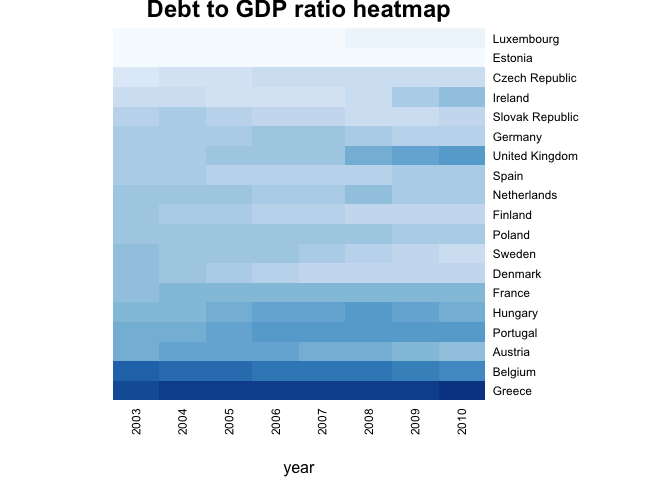

```r
if(!require("pheatmap")) install.packages("pheatmap")
if(!require("RColorBrewer")) install.packages("RColorBrewer")
library("pheatmap")
library("RColorBrewer")

names_num <- c()

for (i in (1:ncol(data_3))) {
  if (sapply(data_3[i], class)[1] == "numeric") {
    names_num <- c(names_num, names(data_3[i]))
  }
}

data_4 <- data_3 %>%
  select(., names_num)

data_4_scaled = as.matrix(scale(data_4))

col_names <- c()
for (name in (colnames(data_4_scaled))){
 col_names <- c(col_names, as.numeric(unlist(str_extract_all(name,"[[:digit:]]{4}"))))
}

colnames(data_4_scaled) <- col_names

heatmap(data_4_scaled, Colv = NA, Rowv = NA, scale="column", col = colorRampPalette(brewer.pal(8, "Blues"))(25), main="Debt to GDP ratio heatmap", cexRow = 0.9, cexCol = 0.9, xlab="year")
```